# Simulations

2026-06-04

# Simulations

## Type I error

At $\alpha = 5\%$, Bradley’s liberal robustness criterion treats empirical rejection rates between $2.5\%$ and $7.5\%$ as acceptable [@Bradley:1978]. Abbreviations are: F = Fisher’s one-way ANOVA; W = Welch’s heteroscedastic ANOVA; L = Levene gate selecting F or W; KW = Kruskal–Wallis; SW = Shapiro–Wilk gate selecting W or KW; SW+L = Shapiro–Wilk gate selecting KW or, if the parametric branch is retained, Levene gate selecting F or W. In the Type I simulations, $n$ denotes the common per-group sample size in balanced rows; in unbalanced rows, $\bar n$ denotes the mean per-group sample size. The unbalanced group sizes are
$$(n_1,n_2,n_3,n_4)\approx\bar n(0.5,0.8,1.2,1.5),$$
rounded to the nearest integers; therefore the realised mean group size is not guaranteed to equal exactly $\bar n$.

In contrast to the normal distribution, where mean and variance are independent parameters, this is not the case for the Gamma distribution $G \sim \Gamma(\alpha,\theta)$, with shape parameter $\alpha>0$ and scale parameter $\theta>0$. The mean is $E(G)=\alpha\theta$, whereas the variance is $\mathrm{Var}(G)=\alpha\theta^2$. The corresponding skewness is $2/\sqrt{\alpha}$, and the kurtosis is $3+6/\alpha$, so the excess kurtosis is $6/\alpha$ [@Forbes:2010, p. 109]. In the simulations, $\theta=1$ and $\alpha\in\{16,4,1,0.25\}$, followed by standardisation $Z=(G-\alpha\theta)/(\theta\sqrt{\alpha})$.

In the identical-distribution setting, both relevant null hypotheses are true: equal means for F, W, and L, and equal rank distributions for KW; SW and SW+L both remain within Bradley bounds in all conditions, showing that the automatic route does not inflate rejection when both candidate null hypotheses are true (Figure @ref(fig:route1-identical-typeI)).

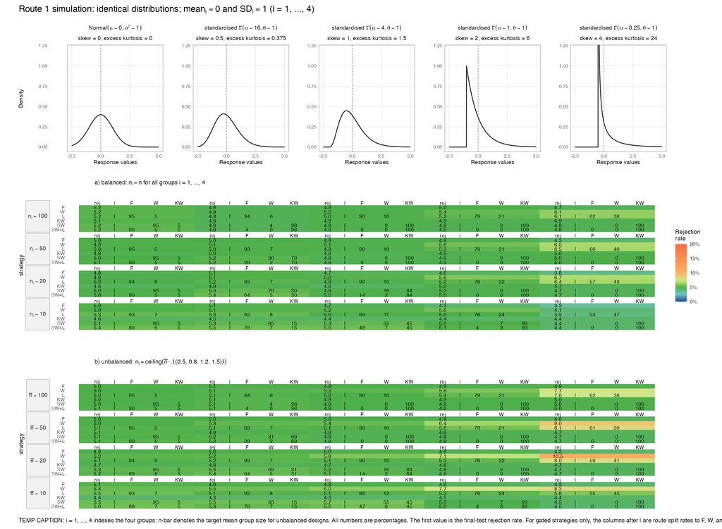

Route 1 simulation under identical distributions and identical means, with maximum Gamma skewness 4. The heatmap shows empirical rejection rates at alpha = 5%; green marks Bradley’s 2.5% to 7.5% range, with darkest green at 5%. The upper panels show the corresponding population PDFs; dashed vertical lines mark the common population mean. In balanced rows, n is the common per-group sample size; in unbalanced rows, n denotes the mean per-group sample size, with group sizes nearest to n(0.5,0.8,1.2,1.5). Abbreviations: F = Fisher’s one-way ANOVA; W = Welch’s heteroscedastic ANOVA; L = Levene gate selecting F or W; KW = Kruskal–Wallis; SW = Shapiro–Wilk gate selecting W or KW; SW+L = Shapiro–Wilk gate selecting KW or, if the parametric branch is retained, Levene gate selecting F or W. SW and SW+L cells show final-test rejection rates plus route probabilities. Because distributions are identical, both equal-means and equal-rank-distribution null hypotheses are true.

Summary of Route 1 rejection rates under identical distributions.

| Strategy | $H_0$ tested | $H_0$ rejection | Outside Bradley bounds |
| --- | --- | --- | --- |
| F | equal means | 4.77% | 0.0% |
| W | equal means | 5.83% | 12.5% |
| L | equal means | 5.42% | 7.5% |
| KW | equal rank distributions | 4.75% | 0.0% |
| SW | selected final-test $H_0$ | 5.01% | 0.0% |
| SW+L | selected final-test $H_0$ | 5.03% | 0.0% |

In the unequal-distribution setting, the equal-means null remains true, but the Kruskal–Wallis null is false because group distributions differ in spread; hence standalone Kruskal–Wallis is not part of the mean-null Type I comparison. Welch has fewer Bradley-bound violations than Fisher and the Levene-gated route, so the Levene variance gate adds little as a Fisher/Welch decision rule. The full SW gate often routes to Kruskal–Wallis under skewness, which is defensible only if the automatic procedure is read as a visible switch from testing means to testing rank distributions (Figure @ref(fig:route1-unequal-mean-null-rejection)).

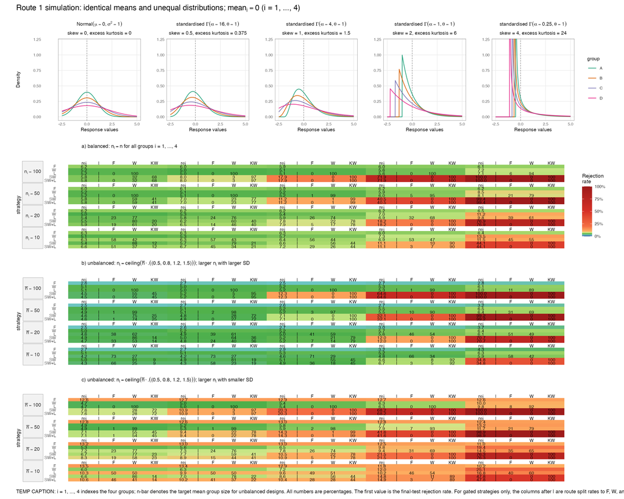

Route 1 simulation under identical means but unequal distributions, with maximum Gamma skewness 4. The heatmap shows empirical rejection rates at alpha = 5%; green marks Bradley’s 2.5% to 7.5% range, with darkest green at 5%. The upper panels show the corresponding population PDFs; dashed vertical lines mark the common population mean. In balanced rows, n is the common per-group sample size; in unbalanced rows, n denotes the mean per-group sample size, with group sizes nearest to n(0.5,0.8,1.2,1.5). Unequal-SD rows use SD = 1.0, 1.3, 1.7, 2.2, with the larger-n/larger-SD and larger-n/smaller-SD panels reversing the pairing of n and SD. Abbreviations: F = Fisher’s one-way ANOVA; W = Welch’s heteroscedastic ANOVA; L = Levene gate selecting F or W; SW = Shapiro–Wilk gate selecting W or KW; SW+L = Shapiro–Wilk gate selecting KW or, if the parametric branch is retained, Levene gate selecting F or W. F, W, and L assess the equal-means null; SW and SW+L report final-test rejection rates plus route probabilities. Standalone KW is omitted because equal rank distributions are not the ground-truth null in these rows.

Summary of Route 1 rejection rates under equal means and unequal distributions.

| Strategy | $H_0$ tested | $H_0$ rejection | Outside Bradley bounds |
| --- | --- | --- | --- |
| Fisher | equal means | 7.20% | 33.3% |
| Welch | equal means | 6.81% | 16.7% |
| Levene F/W | equal means | 6.70% | 23.3% |
| SW | selected final-test $H_0$ | 27.15% | 60.0% |
| SW+L | selected final-test $H_0$ | 27.39% | 65.0% |

## Power simulations

Power was estimated as the rejection probability under ordered location shifts of 0, 0.25, 0.50, and 0.75 SD across four balanced homoscedastic groups. In the normal and mildly skewed cases, the parametric routes have the highest power; in strongly skewed cases, Kruskal–Wallis becomes dominant. The SW+L route follows this switch and is equal or closest to the best-performing strategy across skewness levels. In the normal four-group corner, the small Fisher advantage over Welch follows directly from Eq. @ref(eq:welch-anova-four-groups), $\frac{F}{F_W}=1+3/[5(n-1)]$ (Figure @ref(fig:route1-power-skew-sweep)). Here $n$ denotes the per-group sample size; the total sample size is $N=4n$.

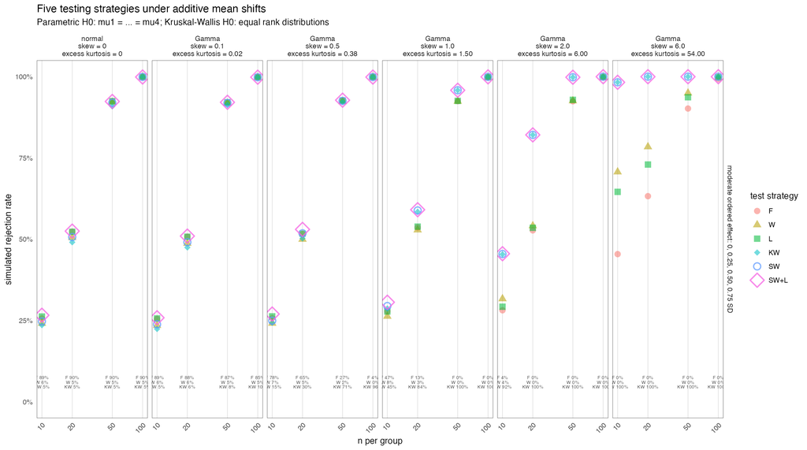

Power simulation under ordered additive group shifts of 0, 0.25, 0.50, and 0.75 SD. The y-axis shows the simulated rejection rate at alpha = 5% for six strategies across skewness and per-group sample size n; total sample size is N = 4n. The data-generating difference is only additive: group means are shifted by 0, 0.25, 0.50, and 0.75 SD. Abbreviations: F = Fisher; W = Welch; L = Levene gate; KW = Kruskal–Wallis; SW = Shapiro–Wilk gate selecting W or KW; SW+L = Shapiro–Wilk gate selecting KW or, if the parametric branch is retained, Levene gate selecting F or W. Bottom labels show SW+L gate decisions. Kruskal–Wallis tests ranks; pairwise stochastic equality corresponds to P(X_i > X_j) + 0.5 P(X_i = X_j) = 0.5. Skew = 0 is normal; skew > 0 uses standardised Gamma groups, where skewness and excess kurtosis vary together. The high-skew result is not a contradiction of the CLT: for fixed mean differences, increasing N makes the mean-based tests valid and eventually highly powered even under strong skewness; KW may also approach 100% power because the location shift changes the ordering of observations.

Mean simulated rejection rate by skewness in the power simulation.

| skew | F | W | L | KW | SW | SW+L | best |
| --- | --- | --- | --- | --- | --- | --- | --- |
| 0.0 | 74.1% | 73.3% | 74.2% | 72.7% | 73.5% | 74.3% | SW+L |
| 0.1 | 73.6% | 72.8% | 73.7% | 72.2% | 72.9% | 73.8% | SW+L |
| 0.5 | 74.0% | 73.3% | 74.1% | 73.3% | 73.8% | 74.5% | SW+L |
| 1.0 | 74.8% | 74.3% | 74.8% | 76.6% | 76.8% | 77.1% | SW+L |
| 2.0 | 74.6% | 75.6% | 75.1% | 85.5% | 85.5% | 85.5% | SW+L |
| 6.0 | 79.6% | 88.8% | 86.2% | 99.7% | 99.7% | 99.7% | KW |

For the normal case (`skew = 0`), the small Fisher advantage over Welch can be checked directly against the algebraic factor from Eq. @ref(eq:welch-anova-four-groups), $\frac{F}{F_W}=1+3/[5(n-1)]$ (Figure @ref(fig:route1-parametric-power)).

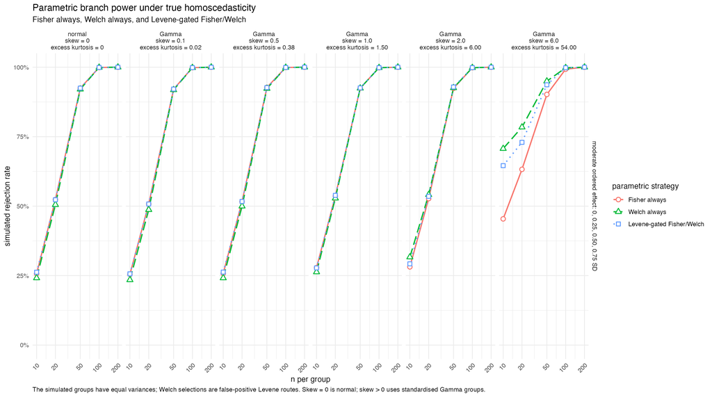

Parametric-branch power under true homoscedasticity. The plot compares Fisher always, Welch always, and the Levene-gated Fisher/Welch route by per-group sample size n.

Fisher/Welch power comparison under true homoscedasticity and normality.

| per-group $n$ | $F/F_W = 1 + 3/[5(n-1)]$ | F power | W power | F/W power |
| --- | --- | --- | --- | --- |
| 10 | 1.0667 | 25.7% | 24.1% | 1.06 |
| 20 | 1.0316 | 52.3% | 50.5% | 1.04 |
| 50 | 1.0122 | 92.5% | 92.1% | 1.00 |
| 100 | 1.0061 | 99.9% | 99.9% | 1.00 |
| 200 | 1.0030 | 100.0% | 100.0% | 1.00 |

Taken together, the simulations support keeping SW+L as the automatic route. This keeps the paper’s general linear model framing coherent: if standardised residual normality is not rejected, homoscedasticity decides whether the analysis remains with Fisher’s ANOVA or moves to Welch’s ANOVA. In the power simulation, the Levene layer shows no power loss relative to SW; under true homoscedasticity it recovers Fisher’s small-sample advantage over Welch at $n=10$ and $n=20$, as expected from Eq. @ref(eq:welch-anova-four-groups). The cost is not power but interpretation: under unequal distributions with equal means, SW+L increasingly reports the rejection rate of KW after the hypothesis switch, so that row must not be read as a Type I error rate for equal means.

$$SE_{\mathrm{MC}}(\hat p)
=
\sqrt{\frac{\hat p(1-\hat p)}{B}} .$$

Here, each simulation cell used $B = 50000$ repetitions. For a rejection rate near the nominal level, $\hat p = 5\%$,

$$SE_{\mathrm{MC}}
=
\sqrt{\frac{0.05(1-0.05)}{50000}}
=
0.10\%.$$

The Monte Carlo standard error is maximal at $\hat p = 50\%$, where it equals $0.22\%$.